# Homework 3

Ashley Cooper, Chloe Swick, Eleanor Thomas

Due 5/19/23

## ESM 204 HW 3

### Question 1

#### Run linear regressions (with an intercept) to estimate the demand curves for DAC and non-DAC consumers. What are 2-3 reasons you can think that may explain the differences in demand you estimate?

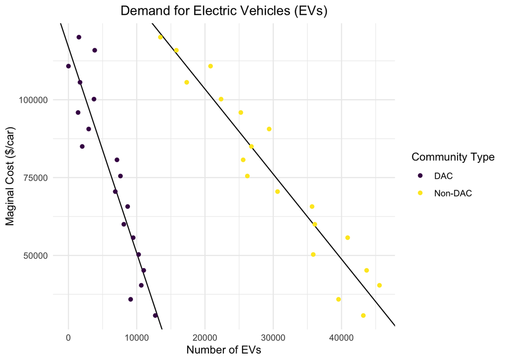

```r
ev_clean <- read_csv(here("HW3_data.csv")) %>%
  janitor::clean_names() %>%
  rename("price" = "price_dollars",
         "dac" = "q_dac",
         "non_dac" = "q_non_dac")

non_dac_lm <- lm(price ~ non_dac, data = ev_clean)
non_dac_coeff <- non_dac_lm$coefficients
###   (Intercept)       non_dac
### 158034.280239     -2.730926

dac_lm <- lm(price ~ dac, data = ev_clean)
dac_coeff <- dac_lm$coefficients
###  (Intercept)           dac
### 116854.835741     -6.611437

ev_pivot <- ev_clean %>%
  pivot_longer(cols = dac:non_dac, names_to = "community", values_to = "quantity")

demand_plot <- ggplot(data = ev_pivot) +
  geom_abline(slope = -2.730926, intercept = 158034.280239) +
  geom_abline(slope = -6.611437, intercept = 116854.835741) +
  geom_point(aes(x = quantity, y = price, color = community)) +
  scale_color_viridis_d(labels = c("DAC", "Non-DAC")) +
  labs(x = "Number of EVs", y = "Maginal Cost ($/car)", color = "Community Type") +
  ggtitle("Demand for Electric Vehicles (EVs)") +
  theme_minimal() +
  theme(plot.title = element_text(hjust = 0.5))

demand_plot
```

Price = 116854.835741 - 6.611437(QDAC)

6.611437(QDAC) = 116854.835741 - Price

*QDAC = (116854.835741 - Price)/6.611437*

Price = 158034.280239 - 2.730926(QNonDAC)

2.730926(QNonDAC) = 158034.280239 - Price

*QNonDAC = (158034.280239 - Price)/2.730926*

#### What are 2-3 reasons you can think that may explain the differences in demand you estimate?

1.) DAC communities have less money to spend on more expensive EVs, so they have an overall lower demand for EVs  
2.) DAC communities may have less access to EV charging infrastructure, or other incentives for using electricity such as rooftop solar  
3.) Non-DAC communities have a more elastic demand curve, because they have more alternative options for transportation.

### Question 2

One kilogram (kg) of lithium is estimated to cause $300 dollars worth of damage in health costs to local communities living near mines. Each EV requires a lithium ion battery containing 63kg of lithium. Assuming there are no other externalities caused by EV production, what is the marginal externality cost per EV produced?

*MEC = $300/kg * 63kg/car MEC = $18,900*

### Question 3

#### What is the aggregate annual demand curve for EVs? What is the supply curve for EVs?

```r
q_dac <- function(price){
    quantity = (116854.835741 - price)/6.611437
    return(quantity)
}

q_non_dac <- function(price){
    quantity = (158034.280239 - price)/2.730926
    return(quantity)
}

q_agg <- function(price){
  if(price > 116854.835741) {
    quantity = (158034.280239 - price)/2.730926
    return(quantity)
    }
if(price <= 116854.835741) {
  quantity = q_dac(price) + q_non_dac(price)
  return(quantity)
}

}


# Qagg = (116854.835741 - price)/6.611437) + (158034.280239 - price)/2.730926
#         17674.65 - price/6.611437 + 57868.39 - price/2.730926
#         75543.04 - -0.5174292 * price



### The current EV price (without any intervention) is $50,000 per vehicle.
### To get the slope of the Supply Curve, P = a + bQ
### b = (P2 - P1)/(Q2 - Q1)
### Goes through the intercept, so (Q1, P1) = (0,0) ; P2 = $50,000 (current EV price) and Q1 = Qagg($50,000)

# q_agg(50000)
# 49671.58

supp_slope <- (50000)/q_agg(50000)
# supp_slope
### 1.006612
```

Aggregate Annual Demand Equation If price > 116854.835741:  
Qagg = (158034.280239 - Price)/2.730926

If price <= 116854.835741:  
Qagg = 75543.04 - 0.5174292(Price)

Supply Equation  
Price = 1.006612(Qagg)

#### What is the “benefit” to producers under the status quo? What is the environmental cost under the status quo?

```r
cs <- 1/2*(116854.835741 - 50000)*q_dac(50000) + 1/2*(158034.280239 - 50000)*q_non_dac(50000)
# cs
# 2474913243

ps <- 1/2*50000*49671.58
# ps
# 1241789500
```

Benefit to Consumers = Consumer Surplus = $2,474,913,243

Benefit to Producers = Producer Surplus = $1,241,789,500

#### What is the environmental cost under the status quo?

```r
### Environmental cost = MEC ($18,900) * Qagg(50,000)
env_cost <- 18900 * 49671.58
# env_cost
# 938792862
```

Environmental Costs = $938,792,862

### Question 4

#### How is the current consumer benefit divided between DAC and non-DAC consumers?

```r
cs_dac <- 1/2*(116854.835741 - 50000)*q_dac(50000)
#cs_dac -- $338,017,973
cs_non_dac <- 1/2*(158034.280239 - 50000)*q_non_dac(50000)
#cs_non_dac -- $2,136,895,270

consumer_benefit_dac <- cs_dac/cs
consumer_benefit_non_dac <- cs_non_dac/cs

# consumer_benefit_dac
# 0.1365777
# consumer_benefit_non_dac
# 0.8634223
```

Currently disadvantaged communities get ~13.66% of the total consumer benefits from EVs, while non-disadvantaged communities enjoy ~86.34% of the total consumer benefits.

### Question 5

#### Derive the optimal EV tax (in $ per vehicle) to internalize the lithium mining externality.

Optimal Tax = MEC at Q*

Because MEC is constant, optimal tax = $18,900/EV

```r
q_agg(50000)
# 49671.58

q_agg(68900)
# 39892.16

q_agg(50000) - q_agg(68900)
# 9779.412
```

#### (a) The amount of EVs produced and consumed

The quantity of EVs would decrease by **~ 9,780** cars, from 49,672 EVs to **39,892 EVs**.

#### (b) The price of EVs

The price of each EV would increase by **$18,900** from $50,000 to **$68,900**.

#### (c) Overall welfare of non-DAC consumers

```r
cs_non_dac_tax <- 1/2*(158034.280239 - 68900)*q_non_dac(68900)
# 1,454,620,139
```

Benefit to non-DAC Consumers w/tax = **$1,454,620,139**  
This is a decrease of **$682,275,131** from a non taxed CS of $\2,136,895,270

#### (d) Overall welfare of DAC consumers

```r
cs_dac_tax <- 1/2*(116854.835741 - 68900)*q_dac(68900)
cs_dac_tax
# 173,915,767
```

Benefit to DAC Consumers w/tax = **$173,915,767**  
This is a decrease of **$164,102,206** from the non taxed CS of $338,017,973 The overall welfare for DAC will be their benefit after the tax is implemented ($173,915,767) minus the environmental damage after the tax of $753,961,824. The DAC consumers will have an overall welfare of **-$580,046,057**.

#### (e) Benefit to EV producers

```r
ps <- 1/2*50000*49671.58
# ps
# 1241789500
ps_tax <- 1/2*68900*39892.16
#1,374,284,912
```

#### (f) Total environmental damage

```r
### Environmental cost = MEC ($18,900) * Qagg(50,000)
#q_agg(68900)
# 39892.16
env_cost_tax <- 18900 * 39892.16

# env_cost no tax
# 938792862
#env_cost_tax
#753,961,824
```